# Las Siete Herramientas de Control de Calidad (QC)

#### 2. Ejemplo de aplicación de la estratificación en un diagrama de Pareto

パレート図での層別の実施例

El pintado de las placas de acero se realiza en dos líneas. Se decidió analizar el contenido de los productos no conformes de un mes mediante un diagrama de Pareto.

[Audio_45](https://drive.google.com/file/d/1TOytDvGpP9Q9IwfBkRB7g6Ua1zGVMHxA/view?usp=drive_link)

```python
sheet = client.open_by_key(SPREADSHEET_ID).worksheet("Sheet14") # 最初のシートを取得

# データを取得
list_of_lists = sheet.get_all_records()
df = pd.DataFrame(list_of_lists)

df.reset_index(drop=True, inplace=True)

df = df.set_index('Ítem no conforme')
df = df.astype('float')

dfA = df.copy()
```

```python
sheet = client.open_by_key(SPREADSHEET_ID).worksheet("Sheet15") # 最初のシートを取得

# データを取得
list_of_lists = sheet.get_all_records()
df = pd.DataFrame(list_of_lists)


df.reset_index(drop=True, inplace=True)

df = df.set_index('Ítem no conforme')
df = df.astype('float')

dfB = df.copy()
```

```python
df_merge = pd.merge(dfA, dfB, left_index=True, right_index=True, suffixes=('_A', '_B'))
df_merge['Número de ítems no conformes'] = df_merge['Número de ítems no conformes_A']+df_merge['Número de ítems no conformes_B']

# Ordenar de mayor a menor de Número de ítems no conformes
df_except_last = df_merge[:-1]
df_sorted = df_except_last.sort_values(by='Número de ítems no conformes', ascending=False)
df_merge = pd.concat([df_sorted, df_merge[-1:]])

# Calucular la acumulación
df_merge['Número acumulado de ítems no conformes'] = df_merge['Número de ítems no conformes'].cumsum()

# Calcular la proporción
df_merge['Tasa (%)'] = np.round(df_merge['Número de ítems no conformes'] / df_merge['Número de ítems no conformes'].sum() * 100,1)

# Calcular la proporción acumulada
df_merge['Tasa acumulada (%)'] = np.round(df_merge['Número de ítems no conformes'].cumsum() / df_merge['Número de ítems no conformes'].sum() * 100,1)

dfC = df_merge[['Número de ítems no conformes','Número acumulado de ítems no conformes','Tasa (%)','Tasa acumulada (%)']]
```

[Audio_46](https://drive.google.com/file/d/1Cmk0n7Rz2-OTkgG2Y2Zr1c8_2RVJIdus/view?usp=drive_link)

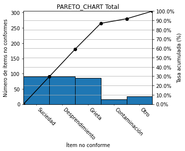

```python
pareto_chart_(dfC, "Total")
```

Se realizó la estratificación por la Línea A y la Línea B y se crearon diagramas de Pareto para cada una. Como resultado, se encontró que en la Línea A, "desigualdad en el color" y "suciedad" representaban aproximadamente el 70% del total, mientras que en la Línea B, "desprendimiento" y "grietas" constituían el mismo porcentaje. Por lo tanto, se decidió investigar las causas de estos dos principales defectos en cada línea.

[Audio_48](https://drive.google.com/file/d/1-5D1R6GoOnsqJHg_puofcceb19JrMslM/view?usp=drive_link)

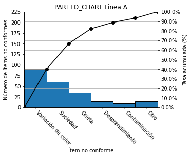

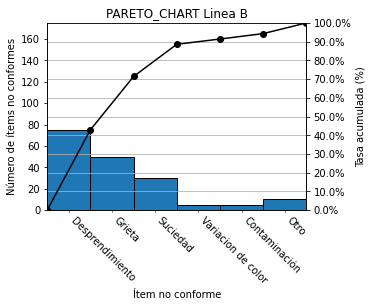

```python
pareto_chart_(dfA, "Linea A")
pareto_chart_(dfB, "Linea B")
```

#### 3. Ejemplo de aplicación de la estratificación en un diagrama de dispersión

散布図での層別の実施例

Es una representación de la relación entre el número de visitantes y las ventas de un día en un centro comercial.

En general parece que **no hay correlación**, pero al estratificar y graficar los productos de bajo precio y uso general (Producto A: circulo azul) y los productos de alto precio y preferencia (Product B: círculo rojo), se observa que el Producto A tiene una **correlación positiva** entre el número de visitantes y las ventas. Por otro lado, el Producto B parece **no tener una relación de correlación**.

[Audio_49](https://drive.google.com/file/d/1vjmyRzC5jCd6Y3gRdtAaZf8W5obVPYlu/view?usp=drive_link)

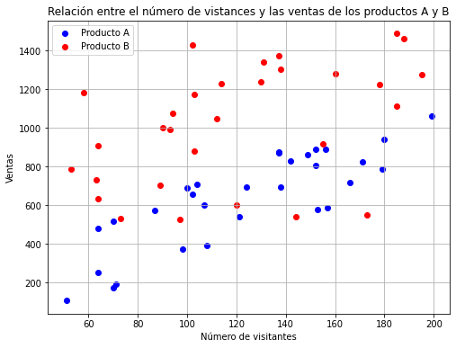

```python
np.random.seed(42)
n = 30

# Product A（Correlación positiva）
x_a = np.random.randint(50, 200, n)  #
y_a = x_a * 5 + np.random.randint(-200, 200, n)  #

# Product B（Sin correlación)
x_b = np.random.randint(50, 200, n)
y_b = np.random.randint(500, 1500, n)  #

# Creación de diagrama de dispersión
plt.figure(figsize=(8, 6))
plt.scatter(x_a, y_a, color='blue', label="Producto A")
plt.scatter(x_b, y_b, color='red', label="Producto B")

# Graph
plt.xlabel("Número de visitantes")
plt.ylabel("Ventas")
plt.title("Relación entre el número de vistances y las ventas de los productos A y B")
plt.legend()
plt.grid(True)
plt.show()
```

## Por favor, responda a las preguntas del examen de práctica a través del siguiente enlace.

[Simulacro de examen](https://forms.gle/2oMKcVhLeAmKnc7H7)

## 7.11

次のそれぞれの状況で各１００個ずつの計量値データを取り、ヒストグラムを描いた。

Se tomaron 100 datos de medición para cada una de las siguientes situaciones y se representaron en un histograma.

### (1)

```
100
```

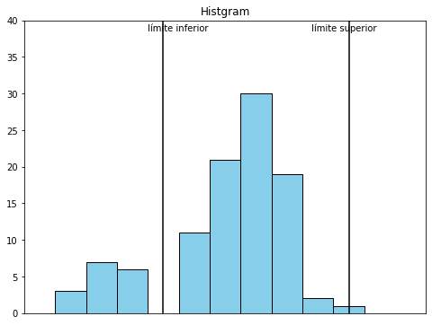

```python
import draw_hist_graph

k = [0,3,8,5,0,11,22,32,16,3,0,0,0]
max_ = 40
lim_min = 34.5
lim_max = 40.5
pic = '11'

draw_hist_graph.f(k, max_, lim_min, lim_max, pic)
```

### (2)

あるボルト製造工程で、異物が混入し締め付けトルクが大きくなった。ボルトを簡易選別し、合格した７０個だけのデータでヒストグラムを描いた。

En un proceso de fabricación de pernos, se introdujeron impurezas que aumentaron el par de apriete. Se realizó una selección simplificada de los pernos y se construyó un histograma utilizando solo los datos de los 70 que pesaron la inspección.

```
70
```

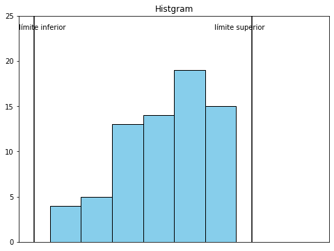

```python
k = [0,4,6,12,14,20,14,0,0,0]
max_ = 25
lim_min = 30.5
lim_max = 37.5
pic = '22'

draw_hist_graph.f(k, max_, lim_min, lim_max, pic)
```

### (3)

ある工程で、品質特性の狙いが異なる品種が３０個混ざって、１００個のロットになった。検査データには明らかな違いがある。

En un proceso, se mezclaron 30 unidades de un tipo con un objetivo diferente de característica de calidad, formando un lote de 100 unidades. Los datos de inspección muestran diferencias evidentes.

```
100
```

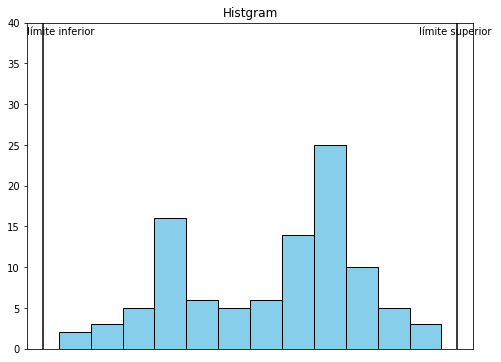

```python
k = [0,2,3,5,16,6,5,6,15,24,11,5,2,0]
max_ = 40
lim_min = 30.5
lim_max = 43.5
pic = '33'

draw_hist_graph.f(k, max_, lim_min, lim_max, pic)
```

### (4)

ある工程では、管理図で見る限り安定状態であり、分布の中心は規格値のほぼ中央にある。

En un determinado proceso, según el diagrama de control, el estado es estable y el centro de la distribución se encuentra casi en el centro de las especificaciones.

```
100
```

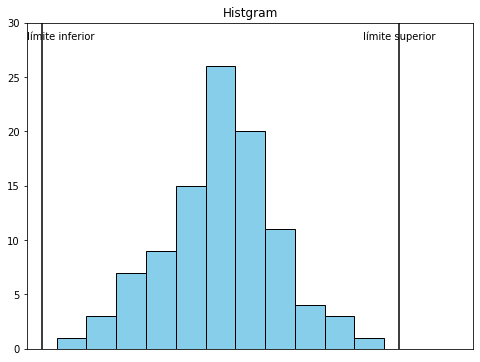

```python
k = [0,1,3,7,10,17,25,19,10,4,3,1,0,0,0]
max_ = 30
lim_min = 30.5
lim_max = 42.5
pic = '44'

draw_hist_graph.f(k, max_, lim_min, lim_max, pic)
```

### (5)

ヒストグラムを描く時、級の幅の計算を間違えて、級の幅を小さく設定した。

Al construir el histograma, se calculó incorrectamente el ancho de clase, configurándose más pequeño de lo adecuado.

```
100
```

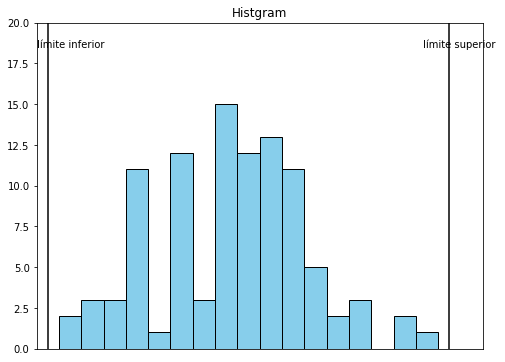

```python
k = [0,3,2,4,10,1,13,2,16,12,13,10,5,2,3,0,2,1,0,1]
max_ = 20
lim_min = 30.5
lim_max = 48.5
pic = '55'

draw_hist_graph.f(k, max_, lim_min, lim_max, pic)
```

### (6)

平均値、ばらつきが異なる３つのラインの部品が混在してしまった。

Se mezclaron piezas de tres líneas diferentes, cada una con una media y una variabilidad distintas.

```
100
```

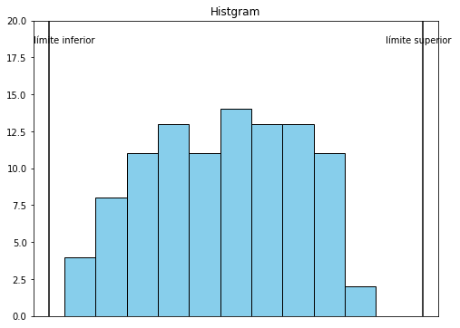

```python
k = [0,4,9,11,12,12,13,14,13,11,1,0,0]
max_ = 20
lim_min = 30.5
lim_max = 42.5
pic = '66'

draw_hist_graph.f(k, max_, lim_min, lim_max, pic)
```

## 7.4

表 7.1は、ある成型部品の不適合項目について３か月間のデータを取り、まとめたものである。パレート図を作成せよ。

La Tabla 7.1 muestra los datos recopilados durante tres meses sobre los elementos no conformes de una pieza moldeada. Se debe crear un diagrama de Pareto.

```python
sheet = client.open_by_key(SPREADSHEET_ID).worksheet("Sheet1") # 最初のシートを取得

# データを取得
list_of_lists = sheet.get_all_records()
df = pd.DataFrame(list_of_lists)

df = df.set_index('Ítem no conforme')

print('Tabla 7.1')
df
```

```
Tabla 7.1
```

| Ítem no conforme | Número de ítems no conformes | Número acumulado de ítems no conformes | Tasa (%) | Tasa acumulada (%) |
| --- | --- | --- | --- | --- |
| Grieta | 276 | 276 | 31.29 | 31.29 |
| Astilla | 240 | 516 | 27.21 | 58.50 |
| Bordes afilados | 180 | 696 | 20.41 | 78.91 |
| Deformación de la forma | 75 | 771 | 8.50 | 87.41 |
| Abolladura | 50 | 821 | 5.67 | 93.08 |
| Arañazo | 30 | 851 | 3.40 | 96.49 |
| Hoyo | 20 | 871 | 2.27 | 98.75 |
| Otro | 11 | 882 | 1.25 | 100.00 |

```python
pareto_chart(df, "7.4")
```

[output not shown]

```
<chart.pareto_chart at 0x12964d0c0>
```

## 7.10

表７．３は電動ドライバーのトルクデータである。データからヒストグラムを作成せよ。

La tabla 7.3 son datos de par de un destornillador eléctrico. Cree un histograma a partir de los datos

```python
# スプレッドシートを開く（URLまたはスプレッドシートIDを使用）
SPREADSHEET_ID = "1Y7lmoNn7CoScUpjWNmBAnL90YTLzdtOUef8EMoeIbTY"
sheet = client.open_by_key(SPREADSHEET_ID).worksheet("Sheet2") # 最初のシートを取得

# データを取得
list_of_lists = sheet.get_all_values()
df = pd.DataFrame(list_of_lists)
df = df.T

df.columns = df.iloc[0]
df = df.drop(df.index[0])
df = df.set_index('index')

df1 = df.iloc[:10].reset_index(drop=True)
df2 = df.iloc[10:20].reset_index(drop=True)
df3 = df.iloc[20:30].reset_index(drop=True)

table = pd.concat([df1.T, df2.T, df3.T], ignore_index=True).reset_index(drop=True)
table.columns = np.arange(1, 11).tolist()
table.index = ['1~10', '11~20', '21~30']

table
```

|  | 1 | 2 | 3 | 4 | 5 | 6 | 7 | 8 | 9 | 10 |
| --- | --- | --- | --- | --- | --- | --- | --- | --- | --- | --- |
| 1~10 | 35.6 | 33.8 | 31.2 | 33.7 | 34.9 | 36.7 | 30.6 | 35.6 | 33.6 | 32.5 |
| 11~20 | 36.9 | 32.3 | 33.8 | 39.7 | 35.7 | 32 | 35 | 34.8 | 35 | 36.6 |
| 21~30 | 36.6 | 34.5 | 32.8 | 34.2 | 37.7 | 33.1 | 35.8 | 34.4 | 36.1 | 34.8 |

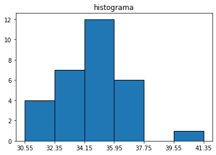

```python
y = df['Valor de medición'].astype("float")

bins = np.arange(30.55, 43., 1.8)
plt.hist(y, bins=bins, edgecolor='black')

custom_xticks = bins
plt.xticks(custom_xticks)

plt.title("histograma")

plt.savefig("Graph3/histgram5_7.png", format="png", dpi=300)
```

## 7.12

３つのラインで生産する部品の重量は、Aラインで母平均100g、母標準偏差5g、Bラインで母平均110g、母標準偏差4g、Cラインで母平均105g、母標準偏差10gであることがわかっている。各ラインからランダムに100個ずつ抜き取り、合計300個を測定したときのヒストグラムは、やや一般型に近い形になる。

Se sabe que el peso de las piezas producidas en tres líneas es el siguiente: en la línea A, la media poblacional es 100g y la desviación estándar poblacional es de 5 g; en la línea B, la media es 110 g y la desviación estándar es de 4 g; y en la línea C, la media es de 105 g y la desviación estándar es de 10 g. Al tomar una muestra aleatoria de 100 piezas de cada línea, obteniendo un total de 300 piezas medidas, el histograma resultando adopta una forma algo cercana a la distribución normal general.

規格下限を85g、規格上限を115gとすると、不適合品が発生しているのは、BラインとCラインである。Cラインでは標準偏差に問題があり、Bラインでは平均値に問題があると考えられる。

Dado que el límite inferior de especificación es 85g y el límite superior es 115g, los productos no conformes se presentan en la línea B y la línea C. En la línea C, el problema se debe a la desviación estándar, mientras que en la línea B, el problema radica en el valor medio.

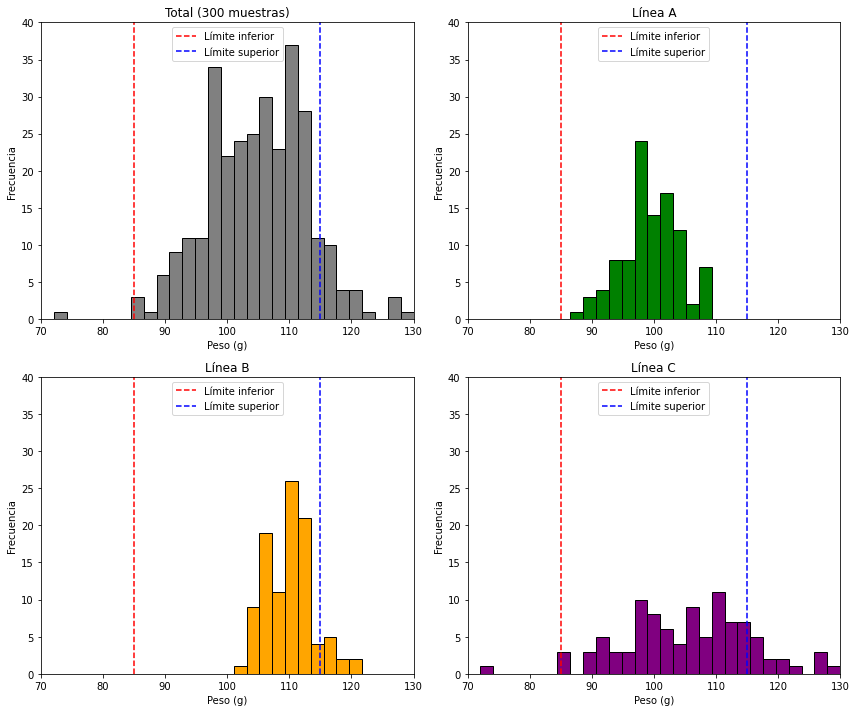

```python
# meedia poblacional y desviacón estándar
mean_A, std_A = 100, 5
mean_B, std_B = 110, 4
mean_C, std_C = 105, 10

# muestra
np.random.seed(42)
data_A = np.random.normal(mean_A, std_A, 100)
data_B = np.random.normal(mean_B, std_B, 100)
data_C = np.random.normal(mean_C, std_C, 100)

# total de 300 piezas
data_total = np.concatenate([data_A, data_B, data_C])

# límite inferior y superior
lower_spec = 85
upper_spec = 115


bins = np.linspace(70, 130, 30)
xlim = (70, 130)
ylim = (0, 40)


fig, axs = plt.subplots(2, 2, figsize=(12, 10))

datasets = [
    (data_total, 'Total (300 muestras)', 'gray'),
    (data_A, 'Línea A', 'green'),
    (data_B, 'Línea B', 'orange'),
    (data_C, 'Línea C', 'purple'),
]

for ax, (data, title, color) in zip(axs.flatten(), datasets):
    ax.hist(data, bins=bins, color=color, edgecolor='black')
    ax.axvline(lower_spec, color='red', linestyle='--', label='Límite inferior')
    ax.axvline(upper_spec, color='blue', linestyle='--', label='Límite superior')
    ax.set_xlim(xlim)
    ax.set_ylim(ylim)
    ax.set_title(title)
    ax.set_xlabel('Peso (g)')
    ax.set_ylabel('Frecuencia')
    ax.legend()

plt.tight_layout()
plt.show()
```

## 7.13

A店では、来客数が増えると売上高が増える。

En la tienda A, cuando aumenta el número de clientes, también aumentan las ventas.

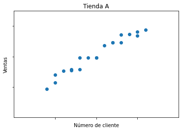

```python
n = 20

x_min, x_max = 4.0, 16.0
x_mean = (x_min + x_max) / 2
y_min, y_max = 10.0, 30.0
y_mean = (y_min + y_max) / 2

correlation = 0.9

x = np.linspace(x_min, x_max, n).round()
y = y_mean + correlation * (y_max - y_mean) / (x_max - x_mean) * (x - x_mean) + np.random.normal(0, 2, n)

plt.scatter(x, y)
plt.xlim(0,20)
plt.ylim(0,35)
plt.xticks([5,10,15],[])
plt.yticks([10,20,30],[])
plt.title('Tienda A')
plt.xlabel('Número de cliente')
plt.ylabel('Ventas')
plt.show()
```

化学薬品Bの反応温度と収率の関係は、ある値にピークがあるようだ。

La relación entre la temperatura de reacción del producto químico B y rendimiento parece tener un pico en cierto valor.

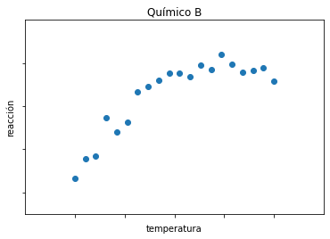

```python
n = 20

x_min, x_max = -3.0, 1.0
x = np.linspace(x_min, x_max, n)
y = -3*x*x + np.random.normal(0, 2, n)

plt.scatter(x, y)
plt.xlim(-4,2)
plt.ylim(-35, 10)
plt.yticks([-30,-20,-10,0],[])
plt.xticks([-3,-2,-1,0,1],[])
plt.title('Químico B')
plt.xlabel('temperatura')
plt.ylabel('reacción')
```

気温が上がるほど、喫茶店Cのホットコーヒーの売上高は落ちるようだ。

Cuanto más sube la temperatura, parece que disminuyen las ventas de café caliente en la cafetería C.

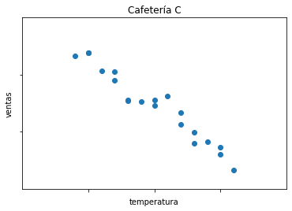

```python
n = 20

x_min, x_max = 4.0, 16.0
x_mean = (x_min + x_max) / 2
y_min, y_max = 5.0, 25.0
y_mean = (y_min + y_max) / 2

correlation = -1

x = np.linspace(x_min, x_max, n).round()
y = y_mean + correlation * (y_max - y_mean) / (x_max - x_mean) * (x - x_mean) + np.random.normal(0, 2, n)

plt.scatter(x, y)
plt.xlim(0,20)
plt.ylim(0,30)
plt.xticks([5,10,15],[])
plt.yticks([10,20],[])
plt.title('Cafetería C')
plt.xlabel('temperatura')
plt.ylabel('ventas')
plt.show()
```

スーパーDのチラシは配布する枚数を多くするほど、来客数は増える。また、チラシに高級肉の特売品を掲載したときは、極端に来客数が増える。

Cuantas más hojas publicitarias distribuye el supermercado D, mayor es el número de clientes que recibe. Además, cuando se incluye una oferta especial de carne de alta calidad en el folleto, el número de clientes aumenta de forma notable.

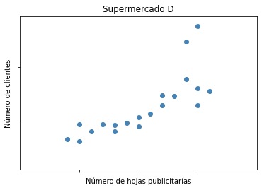

```python
n = 18

x_min, x_max = 4.0, 16.0
x_mean = (x_min + x_max) / 2
y_min, y_max = 5.0, 15.0
y_mean = (y_min + y_max) / 2

correlation = 1

x = np.linspace(x_min, x_max, n).round()
y = y_mean + correlation * (y_max - y_mean) / (x_max - x_mean) * (x - x_mean) + np.random.normal(0, 2, n)

plt.scatter(x, y, color='steelblue')
plt.scatter([14,15],[25,28], color="steelblue")
plt.xlim(0,20)
plt.ylim(0,30)
plt.xticks([5,10,15],[])
plt.yticks([10,20],[])
plt.title('Supermercado D')
plt.xlabel('Número de hojas publicitarías')
plt.ylabel('Número de clientes')
```

コンビニEのおでんの売上高は、冬が圧倒的に多い、気温とおでんの売上高の散布図である。

Las ventas de **Oden** en la tienda de conveniencia E son notablemente más altas en invierno; este es un diagram de dispersión que muestra la relación entre la temperatura y las ventas de orden.

**¿Qué es el oden?**

El oden es un platillo tradicional japonés que se come especialmente en invierno. Consiste en varios ingredientes cocinados lentamente en un caldo a base de salsa de soya. Los ingredientes comunes incluyen huevo cocido, rábano japonés (daikon), pastel de pescado (kamaboko), tofu y konnyaku (un gel hecho de una planta). Todo se sirve caliente y tiene un sabor suave pero muy reconfortante. Es similar a un caldo o guiso ligero.

En Japón, puedes encontrar oden en tiendas de conveniencia, como si fuera tamales calientes o un pozole de mostrador, ¡pero al estilo japonés!

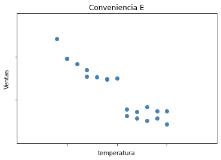

```python
n = 10

x_min, x_max = 4.0, 10.0
x_mean = (x_min + x_max) / 2

x2_min, x2_max = 11.0, 15.0
x2_mean = (x2_min + x2_max) / 2

y_min, y_max = 12.0, 23.0
y_mean = (y_min + y_max) / 2

y2_min, y2_max = 5.0, 8.0
y2_mean = (y2_min + y2_max) / 2

correlation = -0.8
correlation2 = -0.3

x = np.linspace(x_min, x_max, n).round()
x2 = np.linspace(x2_min, x2_max, n).round()
y = y_mean + correlation * (y_max - y_mean) / (x_max - x_mean) * (x - x_mean) + np.random.normal(0, 1, n)
y2 = y2_mean + correlation2 * (y2_max - y2_mean) / (x2_max - x2_mean) * (x2 - x2_mean) + np.random.normal(0, 1, n)

plt.scatter(x, y,  color='steelblue')
plt.scatter(x2, y2, color='steelblue')
plt.xlim(0,20)
plt.ylim(0,30)
plt.xticks([5,10,15],[])
plt.yticks([10,20],[])
plt.title('Conveniencia E')
plt.xlabel('temperatura')
plt.ylabel('Ventas')
plt.show()
```

F大学の学生の身長と数学の点数を調査したところ、ほとんど関係がないことがわかった。

Tras investigar la altura de los estudiantes de la Universidad F y sus puntuaciones en matemáticas, se descubrió que no hay ninguna relación entre ambas variables.

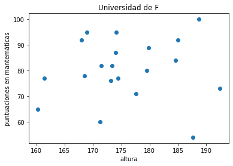

```python
n = 20
np.random.seed(0)
x = np.random.normal(170, 10, n)
y = np.random.normal(80,10, n).round()
while y[np.argmax(y)] > 100:
  y[np.argmax(y)] = 100


plt.scatter(x,y)
plt.title('Universidad de F')
plt.xlabel('altura')
plt.ylabel('puntuaciones en mantemáticas')
```

## 7.16

Q社では、ある製品の不適合品の発生状況を３ヶ月間調査した。不適合項目には、A、B、Dがあり、A、B、D以外のものをその他とした。その後、不適合品の改善活動を行い、結果として全体の件数は半分に減少した。しかし、改善後その他にもなかった不適合項目Cが出現した。そこでA、B、C、D、その他の各不適合項目の割合はどう変化しているのかについて、図のように改善前と改善後のデーターを帯グラフに表した。

La empresa Q realizó una investigación durante tres meses sobre la aparición de productos no conformes de un determinado producto. Los ítems no conformes se clasificaron en A, B y D, mientras que los ítems que no pertenecían a A, B ni D se agruparon como "otros". Posteriormente, se llevó a cabo una actividad de mejora para reducir los productos no conformes, y como resultado, el número total de casos se redujo a la mitad. Sinembargo, después de la mejora, apareció un nuevo ítem no conforme, el C, que no existía antes en la categoría de "otros". Entonces, se representaron en un gráfico de barras las proporciones de cada ítem no conforme (A, B, C, D y otros) antes y después de la mejora, tal como se muestra en la figura.

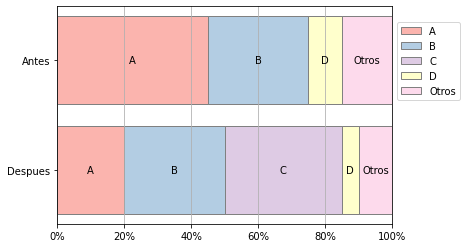

```python
import matplotlib.cm as cm
from matplotlib import ticker

df = pd.read_excel('Data3/Data_7_15.xlsx', index_col=0)
df.sort_index(ascending=False, inplace=True)
DF = df.div(df.sum(axis=1), axis=0)

rows, cols = df.shape

y_position_list = list(range(rows))

plt.rcParams['font.size'] = 10

fig, ax = plt.subplots()

x_offset = [0] * rows

for i, my_col in enumerate(df.columns):
    my_col_data = DF[my_col]

    bar = ax.barh(
        y = y_position_list, #
        width = my_col_data, #
        height = 0.8,
        left = x_offset, #
        color = cm.Pastel1(i/cols),
        label = my_col,
        edgecolor = 'gray'
    )

    x_offset += my_col_data

    for rect, val in zip(bar, my_col_data):
      if rect.get_width() > 0:
        cx = rect.get_x() + rect.get_width() * 0.5
        cy = rect.get_y() + rect.get_height() * 0.5
        ax.text(cx, cy, my_col,
                #"{:.0%}".format(val), # %表記
                color = 'black', #
                ha = 'center', va = 'center', #
        )
ax.set_xlim(0, 1)
ax.set_yticks(y_position_list) #
ax.xaxis.set_major_formatter(ticker.PercentFormatter(1.0))
ax.set_yticklabels(DF.index) #
ax.legend(bbox_to_anchor=(1, 0.95)) #
ax.grid(axis='x')

plt.savefig("Graph3/Fig_7_15_2.png", format="png", dpi=300)
```

1. El ítem cuya proporción se redujo a la mitad después de la mejora es el D.
2. El ítem cuya proporción aumentó después de la mejora es el C.
3. El ítem cuya proporción no cambió después de la mejora es el B.
4. El ítem cuya proporción disminuyó más después de la mejora es el A.
5. El ítem cuya proporción después de la mejora a la de D antes de la mejora es Otros.

```python
notebook_name = 'QCKentei3-2.ipynb'
notebook_name_html = notebook_name.replace(".ipynb",".html")

!jupyter nbconvert --to html {notebook_name}
```

```
[NbConvertApp] Converting notebook QCKentei3-2.ipynb to html
[NbConvertApp] Writing 3418458 bytes to QCKentei3-2.html
```